# 미션2_Elle

```python
country_codes = {
    "Afghanistan": "AFG",
    "Albania": "ALB",
    "Algeria": "DZA",
    "American Samoa": "ASM",
    "Andorra": "AND",
    "Angola": "AGO",
    "Anguilla": "AIA",
    "Antarctica": "ATA",
    "Antigua and Barbuda": "ATG",
    "Argentina": "ARG",
    "Armenia": "ARM",
    "Aruba": "ABW",
    "Australia": "AUS",
    "Austria": "AUT",
    "Azerbaijan": "AZE",
    "Bahamas": "BHS",
    "Bahrain": "BHR",
    "Bangladesh": "BGD",
    "Barbados": "BRB",
    "Belarus": "BYL",
    "Belgium": "BEL",
    "Belize": "BLZ",
    "Benin": "BEN",
    "Bermuda": "BMU",
    "Bhutan": "BTN",
    "Bolivia": "BOL",
    "Bosnia and Herzegovina": "BIH",
    "Botswana": "BWA",
    "Brazil": "BRA",
    "Brunei Darussalam": "BRN",
    "Bulgaria": "BGR",
    "Burkina Faso": "BFA",
    "Burundi": "BDI",
    "Cabo Verde": "CPV",
    "Cambodia": "KHM",
    "Cameroon": "CMR",
    "Canada": "CAN",
    "Cayman Islands": "CYM",
    "Central African Republic": "CAF",
    "Chad": "TCD",
    "Chile": "CHL",
    "China": "CHN",
    "Colombia": "COL",
    "Congo (Democratic Republic)": "COD",
    "Congo (Republic)": "COG",
    "Costa Rica": "CRI",
    "Cote d'Ivoire": "CIV",
    "Croatia": "HRV",
    "Cuba": "CUB",
    "Cyprus": "CYP",
    "Czechia": "CZE",
    "Denmark": "DNK",
    "Djibouti": "DJI",
    "Dominica": "DMA",
    "Dominican Republic": "DOM",
    "Ecuador": "ECU",
    "Egypt": "EGY",
    "El Salvador": "SLV",
    "Estonia": "EST",
    "Ethiopia": "ETH",
    "Fiji": "FJI",
    "Finland": "FIN",
    "France": "FRA",
    "Germany": "DEU",
    "Ghana": "GHA",
    "Greece": "GRC",
    "Hong Kong": "HKG",
    "Hungary": "HUN",
    "Iceland": "ISL",
    "India": "IND",
    "Indonesia": "IDN",
    "Iran": "IRN",
    "Iraq": "IRQ",
    "Ireland": "IRL",
    "Israel": "ISR",
    "Italy": "ITA",
    "Jamaica": "JAM",
    "Japan": "JPN",
    "Jordan": "JOR",
    "Kazakhstan": "KAZ",
    "Kenya": "KEN",
    "Korea (North)": "PRK",
    "Korea (South)": "KOR",
    "Kuwait": "KWT",
    "Malaysia": "MYS",
    "Mexico": "MEX",
    "Netherlands": "NLD",
    "New Zealand": "NZL",
    "Norway": "NOR",
    "Pakistan": "PAK",
    "Philippines": "PHL",
    "Poland": "POL",
    "Portugal": "PRT",
    "Qatar": "QAT",
    "Russian Federation": "RUS",
    "Saudi Arabia": "SAU",
    "Singapore": "SGP",
    "Spain": "ESP",
    "Switzerland": "CHE",
    "Taiwan": "TWN",
    "Thailand": "THA",
    "Turkey": "TUR",
    "Ukraine": "UKR",
    "United Arab Emirates": "ARE",
    "United Kingdom": "GBR",
    "United States": "USA",
    "Vietnam": "VNM"
}
```

```python
country_codes
```

```
{'Afghanistan': 'AFG',
 'Albania': 'ALB',
 'Algeria': 'DZA',
 'American Samoa': 'ASM',
 'Andorra': 'AND',
 'Angola': 'AGO',
 'Anguilla': 'AIA',
 'Antarctica': 'ATA',
 'Antigua and Barbuda': 'ATG',
 'Argentina': 'ARG',
 'Armenia': 'ARM',
 'Aruba': 'ABW',
 'Australia': 'AUS',
 'Austria': 'AUT',
 'Azerbaijan': 'AZE',
 'Bahamas': 'BHS',
 'Bahrain': 'BHR',
 'Bangladesh': 'BGD',
 'Barbados': 'BRB',
 'Belarus': 'BYL',
 'Belgium': 'BEL',
 'Belize': 'BLZ',
 'Benin': 'BEN',
 'Bermuda': 'BMU',
 'Bhutan': 'BTN',
 'Bolivia': 'BOL',
 'Bosnia and Herzegovina': 'BIH',
 'Botswana': 'BWA',
 'Brazil': 'BRA',
 'Brunei Darussalam': 'BRN',
 'Bulgaria': 'BGR',
 'Burkina Faso': 'BFA',
 'Burundi': 'BDI',
 'Cabo Verde': 'CPV',
 'Cambodia': 'KHM',
 'Cameroon': 'CMR',
 'Canada': 'CAN',
 'Cayman Islands': 'CYM',
 'Central African Republic': 'CAF',
 'Chad': 'TCD',
```

[output cut: 52 more lines]

```
 'Portugal': 'PRT',
 'Qatar': 'QAT',
 'Russian Federation': 'RUS',
 'Saudi Arabia': 'SAU',
 'Singapore': 'SGP',
 'Spain': 'ESP',
 'Switzerland': 'CHE',
 'Taiwan': 'TWN',
 'Thailand': 'THA',
 'Turkey': 'TUR',
 'Ukraine': 'UKR',
 'United Arab Emirates': 'ARE',
 'United Kingdom': 'GBR',
 'United States': 'USA',
 'Vietnam': 'VNM'}
```

```python
type(country_codes)
```

```
dict
```

```python
country_codes['Vietnam']
```

```
'VNM'
```

```python
import pandas as pd

hotel_df = pd.read_csv('./hotel_data_modified.csv')
hotel_df.head(3)
```

|  | hotel | is_canceled | lead_time | arrival_date_year | arrival_date_month | arrival_date_week_number | arrival_date_day_of_month | stays_in_weekend_nights | stays_in_week_nights | adults | ... | reserved_room_type | assigned_room_type | booking_changes | agent | company | days_in_waiting_list | required_car_parking_spaces | total_of_special_requests | reservation_status | reservation_status_date |
| --- | --- | --- | --- | --- | --- | --- | --- | --- | --- | --- | --- | --- | --- | --- | --- | --- | --- | --- | --- | --- | --- |
| 0 | Resort Hotel | 0 | 342 | 2015 | July | 27 | 1 | 0 | 0 | 2 | ... | C | C | 3 | NaN | NaN | 0 | 0 | 0 | Check-Out | 2015-07-01 |
| 1 | Resort Hotel | 0 | 737 | 2015 | July | 27 | 1 | 0 | 0 | 2 | ... | C | C | 4 | NaN | NaN | 0 | 0 | 0 | Check-Out | 2015-07-01 |
| 2 | Resort Hotel | 0 | 7 | 2015 | July | 27 | 1 | 0 | 1 | 1 | ... | A | C | 0 | NaN | NaN | 0 | 0 | 0 | Check-Out | 2015-07-02 |

3 rows × 29 columns

```python
import seaborn as sns
import matplotlib.pyplot as plt

sns.set_theme(style="white")
```

```python
hotel_df['country']
```

```
0         PRT
1         PRT
2         GBR
3         GBR
4         GBR
         ...
119385    BEL
119386    FRA
119387    DEU
119388    GBR
119389    DEU
Name: country, Length: 119390, dtype: object
```

```python
{v: k for k, v in country_codes.items()}
```

```
{'AFG': 'Afghanistan',
 'ALB': 'Albania',
 'DZA': 'Algeria',
 'ASM': 'American Samoa',
 'AND': 'Andorra',
 'AGO': 'Angola',
 'AIA': 'Anguilla',
 'ATA': 'Antarctica',
 'ATG': 'Antigua and Barbuda',
 'ARG': 'Argentina',
 'ARM': 'Armenia',
 'ABW': 'Aruba',
 'AUS': 'Australia',
 'AUT': 'Austria',
 'AZE': 'Azerbaijan',
 'BHS': 'Bahamas',
 'BHR': 'Bahrain',
 'BGD': 'Bangladesh',
 'BRB': 'Barbados',
 'BYL': 'Belarus',
 'BEL': 'Belgium',
 'BLZ': 'Belize',
 'BEN': 'Benin',
 'BMU': 'Bermuda',
 'BTN': 'Bhutan',
 'BOL': 'Bolivia',
 'BIH': 'Bosnia and Herzegovina',
 'BWA': 'Botswana',
 'BRA': 'Brazil',
 'BRN': 'Brunei Darussalam',
 'BGR': 'Bulgaria',
 'BFA': 'Burkina Faso',
 'BDI': 'Burundi',
 'CPV': 'Cabo Verde',
 'KHM': 'Cambodia',
 'CMR': 'Cameroon',
 'CAN': 'Canada',
 'CYM': 'Cayman Islands',
 'CAF': 'Central African Republic',
 'TCD': 'Chad',
```

[output cut: 52 more lines]

```
 'PRT': 'Portugal',
 'QAT': 'Qatar',
 'RUS': 'Russian Federation',
 'SAU': 'Saudi Arabia',
 'SGP': 'Singapore',
 'ESP': 'Spain',
 'CHE': 'Switzerland',
 'TWN': 'Taiwan',
 'THA': 'Thailand',
 'TUR': 'Turkey',
 'UKR': 'Ukraine',
 'ARE': 'United Arab Emirates',
 'GBR': 'United Kingdom',
 'USA': 'United States',
 'VNM': 'Vietnam'}
```

```python
country_codes = {v: k for k, v in country_codes.items()}
```

```python
hotel_df['country'].map(country_codes)
```

```
0               Portugal
1               Portugal
2         United Kingdom
3         United Kingdom
4         United Kingdom
               ...
119385           Belgium
119386            France
119387           Germany
119388    United Kingdom
119389           Germany
Name: country, Length: 119390, dtype: object
```

먼저, 해당 데이터를 확인해보자.

```python
hotel_df.shape
```

```
(119390, 29)
```

hotel_df 데이터는 119,390개의 행과 29개의 열로 구성되어 있다.

```python
hotel_df.dtypes
```

```
hotel                              object
is_canceled                         int64
lead_time                           int64
arrival_date_year                   int64
arrival_date_month                 object
arrival_date_week_number            int64
arrival_date_day_of_month           int64
stays_in_weekend_nights             int64
stays_in_week_nights                int64
adults                              int64
children                          float64
babies                              int64
meal                               object
country                            object
market_segment                     object
distribution_channel               object
is_repeated_guest                   int64
previous_cancellations              int64
previous_bookings_not_canceled      int64
reserved_room_type                 object
assigned_room_type                 object
booking_changes                     int64
agent                             float64
company                           float64
days_in_waiting_list                int64
required_car_parking_spaces         int64
total_of_special_requests           int64
reservation_status                 object
reservation_status_date            object
dtype: object
```

```python
hotel_df.info()
```

```
<class 'pandas.core.frame.DataFrame'>
RangeIndex: 119390 entries, 0 to 119389
Data columns (total 29 columns):
 #   Column                          Non-Null Count   Dtype
---  ------                          --------------   -----
 0   hotel                           119390 non-null  object
 1   is_canceled                     119390 non-null  int64
 2   lead_time                       119390 non-null  int64
 3   arrival_date_year               119390 non-null  int64
 4   arrival_date_month              119390 non-null  object
 5   arrival_date_week_number        119390 non-null  int64
 6   arrival_date_day_of_month       119390 non-null  int64
 7   stays_in_weekend_nights         119390 non-null  int64
 8   stays_in_week_nights            119390 non-null  int64
 9   adults                          119390 non-null  int64
```

[output cut: 21 more lines]

## 데이터 사전 점검

본격적으로 데이터를 처리하고 모델 학습을 진행하기에 앞서,  
데이터에 오류나 오염이 존재하는지 먼저 확인한다.

이 단계에서는 **결측치와 이상치**뿐만 아니라,  
**중복된 데이터**나 **비정상적인 값**이 포함되어 있는지도 함께 점검한다.

이러한 사전 점검 과정은  
이후 분석 결과와 모델 성능에 직접적인 영향을 미치기 때문에  
매우 중요한 단계이다.

```python
hotel_df.isnull().sum()
```

```
hotel                                  0
is_canceled                            0
lead_time                              0
arrival_date_year                      0
arrival_date_month                     0
arrival_date_week_number               0
arrival_date_day_of_month              0
stays_in_weekend_nights                0
stays_in_week_nights                   0
adults                                 0
children                               4
babies                                 0
meal                                   0
country                              488
market_segment                         0
distribution_channel                   0
is_repeated_guest                      0
previous_cancellations                 0
previous_bookings_not_canceled         0
reserved_room_type                     0
assigned_room_type                     0
booking_changes                        0
agent                              16340
company                           112593
days_in_waiting_list                   0
required_car_parking_spaces            0
total_of_special_requests              0
reservation_status                     0
reservation_status_date                0
dtype: int64
```

## 결측값 처리 (Handling Missing Values)

먼저 데이터에 포함된 결측값의 현황을 확인한다.  
`hotel_df`에는 다음과 같은 결측값이 존재한다.

- **children**: 4개
- **country**: 488개
- **agent**: 16,340개
- **company**: 112,593개

### 1. `children` 결측값 처리

`children` 컬럼의 결측값은 4개로 매우 적어  
전체 데이터에 미치는 영향이 크지 않다고 판단하였다.

해당 결측값은 **어린이를 동반하지 않은 예약**으로 가정하고  
`0`으로 대체하여 분석을 진행한다.

### 2. `country` 결측값 처리

`country` 컬럼에는 488개의 결측값이 존재한다.  
국가 정보는 그 자체로 하나의 범주로 의미를 가질 수 있으므로,

결측값을 제거하지 않고  
**`Unknown`이라는 별도의 카테고리로 대체**하여 처리한다.

### 3. `company` 컬럼 제거

`company` 컬럼은 전체 119,390건 중  
112,593건이 결측값으로, 결측 비율이 매우 높다.

대부분 **개인 예약**으로 판단되며,  
분석에 유의미한 정보를 제공하기 어렵다고 판단하여  
해당 컬럼은 분석 대상에서 제외한다.

### 4. `agent` 결측값 처리

`agent` 컬럼의 결측값은  
**여행사를 통하지 않은 예약**으로 해석할 수 있다.

여행사 예약과 비여행사 예약 간의 비교가 가능하도록,  
해당 결측값을 `0`으로 대체하여  
**범주형 변수로 활용**한다.

추후 이를 통해  
여행사 예약 여부에 따른 **취소율 차이**를 분석할 수 있다.

이와 같은 결측값 처리 전략을 통해  
데이터의 손실을 최소화하면서도  
분석에 필요한 정보는 최대한 유지하고자 한다.

```python
# children과 agent 결측치 0으로 대체
hotel_df['children'] = hotel_df['children'].fillna(0)
hotel_df['agent'] = hotel_df['agent'].fillna(0)

# country 결측치를 Unknown으로 대체
hotel_df['country'] = hotel_df['country'].fillna("Unknown")

# company 열 삭제
hotel_df = hotel_df.drop(columns='company')
```

이제 결측값이 모두 없어지고 반영이 모두 됐는지 확인한다.

```python
hotel_df.isnull().sum()
```

```
hotel                             0
is_canceled                       0
lead_time                         0
arrival_date_year                 0
arrival_date_month                0
arrival_date_week_number          0
arrival_date_day_of_month         0
stays_in_weekend_nights           0
stays_in_week_nights              0
adults                            0
children                          0
babies                            0
meal                              0
country                           0
market_segment                    0
distribution_channel              0
is_repeated_guest                 0
previous_cancellations            0
previous_bookings_not_canceled    0
reserved_room_type                0
assigned_room_type                0
booking_changes                   0
agent                             0
days_in_waiting_list              0
required_car_parking_spaces       0
total_of_special_requests         0
reservation_status                0
reservation_status_date           0
dtype: int64
```

확인해보면 모두 0으로 결측값이 더이상 없는 것을 잘 확인할 수 있다.

```python
hotel_df.info()
```

```
<class 'pandas.core.frame.DataFrame'>
RangeIndex: 119390 entries, 0 to 119389
Data columns (total 28 columns):
 #   Column                          Non-Null Count   Dtype
---  ------                          --------------   -----
 0   hotel                           119390 non-null  object
 1   is_canceled                     119390 non-null  int64
 2   lead_time                       119390 non-null  int64
 3   arrival_date_year               119390 non-null  int64
 4   arrival_date_month              119390 non-null  object
 5   arrival_date_week_number        119390 non-null  int64
 6   arrival_date_day_of_month       119390 non-null  int64
 7   stays_in_weekend_nights         119390 non-null  int64
 8   stays_in_week_nights            119390 non-null  int64
 9   adults                          119390 non-null  int64
```

[output cut: 20 more lines]

```python
hotel_df.describe()
```

|  | is_canceled | lead_time | arrival_date_year | arrival_date_week_number | arrival_date_day_of_month | stays_in_weekend_nights | stays_in_week_nights | adults | children | babies | is_repeated_guest | previous_cancellations | previous_bookings_not_canceled | booking_changes | agent | days_in_waiting_list | required_car_parking_spaces | total_of_special_requests |
| --- | --- | --- | --- | --- | --- | --- | --- | --- | --- | --- | --- | --- | --- | --- | --- | --- | --- | --- |
| count | 119390.000000 | 119390.000000 | 119390.000000 | 119390.000000 | 119390.000000 | 119390.000000 | 119390.000000 | 119390.000000 | 119390.000000 | 119390.000000 | 119390.000000 | 119390.000000 | 119390.000000 | 119390.000000 | 119390.000000 | 119390.000000 | 119390.000000 | 119390.000000 |
| mean | 0.370416 | 104.011416 | 2016.156554 | 27.165173 | 15.798241 | 0.927599 | 2.500302 | 1.856403 | 0.103886 | 0.007949 | 0.031912 | 0.087118 | 0.137097 | 0.221124 | 74.828319 | 2.321149 | 0.062518 | 0.571363 |
| std | 0.482918 | 106.863097 | 0.707476 | 13.605138 | 8.780829 | 0.998613 | 1.908286 | 0.579261 | 0.398555 | 0.097436 | 0.175767 | 0.844336 | 1.497437 | 0.652306 | 107.141953 | 17.594721 | 0.245291 | 0.792798 |
| min | 0.000000 | 0.000000 | 2015.000000 | 1.000000 | 1.000000 | 0.000000 | 0.000000 | 0.000000 | 0.000000 | 0.000000 | 0.000000 | 0.000000 | 0.000000 | 0.000000 | 0.000000 | 0.000000 | 0.000000 | 0.000000 |
| 25% | 0.000000 | 18.000000 | 2016.000000 | 16.000000 | 8.000000 | 0.000000 | 1.000000 | 2.000000 | 0.000000 | 0.000000 | 0.000000 | 0.000000 | 0.000000 | 0.000000 | 7.000000 | 0.000000 | 0.000000 | 0.000000 |
| 50% | 0.000000 | 69.000000 | 2016.000000 | 28.000000 | 16.000000 | 1.000000 | 2.000000 | 2.000000 | 0.000000 | 0.000000 | 0.000000 | 0.000000 | 0.000000 | 0.000000 | 9.000000 | 0.000000 | 0.000000 | 0.000000 |
| 75% | 1.000000 | 160.000000 | 2017.000000 | 38.000000 | 23.000000 | 2.000000 | 3.000000 | 2.000000 | 0.000000 | 0.000000 | 0.000000 | 0.000000 | 0.000000 | 0.000000 | 152.000000 | 0.000000 | 0.000000 | 1.000000 |
| max | 1.000000 | 737.000000 | 2017.000000 | 53.000000 | 31.000000 | 19.000000 | 50.000000 | 55.000000 | 10.000000 | 10.000000 | 1.000000 | 26.000000 | 72.000000 | 21.000000 | 535.000000 | 391.000000 | 8.000000 | 5.000000 |

결측치 제거 후 실수를 정수로 바꿔준다.

```python
hotel_df['children'] = hotel_df['children'].astype(int)
```

**agent**의 경우 **agent ID** 이므로,  
아래처럼 EDA를 사용하여 여행사 통한 예약과 아닌 예약으로 구분이 가도록 나눠준다.

```python
hotel_df['agent_group'] = hotel_df['agent'].apply(
    lambda x: 'No Agent' if x == 0 else 'With Agent'
)
```

**agent_group** 변수를 통해 여행사 예약 여부에 대한 정보가 충분히 반영되었으므로, 원본 **agent** 컬럼은 더 이상 필요하지 않아 분석 대상에서 제외한다.

```python
hotel_df = hotel_df.drop(columns='agent')
```

```python
hotel_df.info()
```

```
<class 'pandas.core.frame.DataFrame'>
RangeIndex: 119390 entries, 0 to 119389
Data columns (total 28 columns):
 #   Column                          Non-Null Count   Dtype
---  ------                          --------------   -----
 0   hotel                           119390 non-null  object
 1   is_canceled                     119390 non-null  int64
 2   lead_time                       119390 non-null  int64
 3   arrival_date_year               119390 non-null  int64
 4   arrival_date_month              119390 non-null  object
 5   arrival_date_week_number        119390 non-null  int64
 6   arrival_date_day_of_month       119390 non-null  int64
 7   stays_in_weekend_nights         119390 non-null  int64
 8   stays_in_week_nights            119390 non-null  int64
 9   adults                          119390 non-null  int64
```

[output cut: 20 more lines]

```python
hotel_df
```

|  | hotel | is_canceled | lead_time | arrival_date_year | arrival_date_month | arrival_date_week_number | arrival_date_day_of_month | stays_in_weekend_nights | stays_in_week_nights | adults | ... | previous_bookings_not_canceled | reserved_room_type | assigned_room_type | booking_changes | days_in_waiting_list | required_car_parking_spaces | total_of_special_requests | reservation_status | reservation_status_date | agent_group |
| --- | --- | --- | --- | --- | --- | --- | --- | --- | --- | --- | --- | --- | --- | --- | --- | --- | --- | --- | --- | --- | --- |
| 0 | Resort Hotel | 0 | 342 | 2015 | July | 27 | 1 | 0 | 0 | 2 | ... | 0 | C | C | 3 | 0 | 0 | 0 | Check-Out | 2015-07-01 | No Agent |
| 1 | Resort Hotel | 0 | 737 | 2015 | July | 27 | 1 | 0 | 0 | 2 | ... | 0 | C | C | 4 | 0 | 0 | 0 | Check-Out | 2015-07-01 | No Agent |
| 2 | Resort Hotel | 0 | 7 | 2015 | July | 27 | 1 | 0 | 1 | 1 | ... | 0 | A | C | 0 | 0 | 0 | 0 | Check-Out | 2015-07-02 | No Agent |
| 3 | Resort Hotel | 0 | 13 | 2015 | July | 27 | 1 | 0 | 1 | 1 | ... | 0 | A | A | 0 | 0 | 0 | 0 | Check-Out | 2015-07-02 | With Agent |
| 4 | Resort Hotel | 0 | 14 | 2015 | July | 27 | 1 | 0 | 2 | 2 | ... | 0 | A | A | 0 | 0 | 0 | 1 | Check-Out | 2015-07-03 | With Agent |
| ... | ... | ... | ... | ... | ... | ... | ... | ... | ... | ... | ... | ... | ... | ... | ... | ... | ... | ... | ... | ... | ... |
| 119385 | City Hotel | 0 | 23 | 2017 | August | 35 | 30 | 2 | 5 | 2 | ... | 0 | A | A | 0 | 0 | 0 | 0 | Check-Out | 2017-09-06 | With Agent |
| 119386 | City Hotel | 0 | 102 | 2017 | August | 35 | 31 | 2 | 5 | 3 | ... | 0 | E | E | 0 | 0 | 0 | 2 | Check-Out | 2017-09-07 | With Agent |
| 119387 | City Hotel | 0 | 34 | 2017 | August | 35 | 31 | 2 | 5 | 2 | ... | 0 | D | D | 0 | 0 | 0 | 4 | Check-Out | 2017-09-07 | With Agent |
| 119388 | City Hotel | 0 | 109 | 2017 | August | 35 | 31 | 2 | 5 | 2 | ... | 0 | A | A | 0 | 0 | 0 | 0 | Check-Out | 2017-09-07 | With Agent |
| 119389 | City Hotel | 0 | 205 | 2017 | August | 35 | 29 | 2 | 7 | 2 | ... | 0 | A | A | 0 | 0 | 0 | 2 | Check-Out | 2017-09-07 | With Agent |

119390 rows × 28 columns

## 데이터 정제

결측값 처리가 완료된 이후에는,  
데이터에 남아 있는 **논리적 오류, 이상치, 의미상 중복 및 누수 변수**를 추가로 정제한다.  
이 과정은 취소율 분석의 신뢰도를 높이기 위해 필수적인 단계이다.

### 1. 논리적으로 성립하지 않는 값 제거

예약이 존재함에도 불구하고 실제 상황으로 보기 어려운 경우를 먼저 제거한다.

- **숙박 인원이 전혀 없는 경우**
  - `adults == 0` AND `children == 0` AND `babies == 0`
- **숙박 일수가 0인 경우**
  - `stays_in_week_nights + stays_in_weekend_nights == 0`

위 조건에 해당하는 데이터는 실제 예약 데이터로 보기 어렵다고 판단하여  
분석 대상에서 제외한다.

### 2. 이상치 처리

이상치는 특히 **취소율 분석에 큰 영향을 미칠 수 있으므로**  
사전에 확인하고 적절히 처리한다.

다음 변수들을 중심으로 이상치를 점검한다.

- **`lead_time`**
  - 예약 시점부터 도착까지의 기간이 지나치게 큰 경우
  - → 제거하거나 구간화(bin) 처리
- **`booking_changes`**
  - 예약 변경 횟수가 비정상적으로 많은 경우
  - → 상한 처리(capping) 또는 제거
- **`days_in_waiting_list`**
  - 대기 기간이 극단적으로 긴 경우
  - → 제거 또는 이진화/구간화 처리

이러한 처리를 통해 소수의 극단값이 분석 결과를 왜곡하는 것을 방지한다.

### 3. 의미상 중복 및 데이터 누수 변수 제거

다음 변수들은 **예약 취소 결과 이후에 결정되거나 결과 자체를 포함하는 변수**로,  
취소 원인 분석에 사용할 경우 데이터 누수를 유발할 수 있다.

### 4. 범주형 변수 카테고리 정리 (재분류)

일부 범주형 변수는 의미가 중복되거나,  
관측 수가 매우 적어 분석 시 노이즈를 유발할 수 있다.

해당 변수들은 **제거가 아닌 재분류/통합** 대상으로 처리한다.

**!! 이러한 데이터 정제 과정을 통해  
분석 결과의 신뢰도와 해석 가능성을 높이고,  
예약 취소와 실제로 연관된 요인에 집중할 수 있도록 하였다.

```python
# 숙박 인원 0인 데이터 확인

invalid_guests = hotel_df[
    (hotel_df['adults'] == 0) &
    (hotel_df['children'] == 0) &
    (hotel_df['babies'] == 0)]

len(invalid_guests)
```

```
180
```

```python
# 숙박 일수 0인 데이터 확인

invalid_stays = hotel_df[
    (hotel_df['stays_in_week_nights'] + hotel_df['stays_in_weekend_nights']) == 0]

len(invalid_stays)
```

```
715
```

```python
# 위 두 조건 제거

hotel_df = hotel_df[
    ~(((hotel_df['adults'] == 0) &
        (hotel_df['children'] == 0) &
        (hotel_df['babies'] == 0)) |
        ((hotel_df['stays_in_week_nights'] +
        hotel_df['stays_in_weekend_nights']) == 0))]
```

```python
# 의미상 중복이 있거나 데이터 누수가 있을 법한 변수 제거

hotel_df = hotel_df.drop(columns=['reservation_status', 'reservation_status_date'])
```

먼저 분포를 살핀다.

```python
hotel_df['lead_time'].describe()
```

```
count    118565.000000
mean        104.505832
std         106.915519
min           0.000000
25%          18.000000
50%          70.000000
75%         161.000000
max         709.000000
Name: lead_time, dtype: float64
```

```python
hotel_df['lead_time'].sort_values(ascending=False).head(10)
```

```
4182     709
65238    629
65253    629
65240    629
65241    629
65239    629
65237    629
65252    629
65231    629
65243    629
Name: lead_time, dtype: int64
```

```python
# lead_time 이상치 구간화

hotel_df['lead_time_bin'] = pd.cut(
    hotel_df['lead_time'],
    bins=[-1, 30, 90, 180, 365, 1000],
    labels=['<1M', '1-3M', '3-6M', '6-12M', '>1Y'])
```

예약 시점과 도착 시점 간의 거리를 **구간화**하여,  
장기 예약과 단기 예약 간의 **취소 패턴을 비교**할 수 있다.

```python
hotel_df['booking_changes'].describe()
```

```
count    118565.000000
mean          0.218361
std           0.637629
min           0.000000
25%           0.000000
50%           0.000000
75%           0.000000
max          18.000000
Name: booking_changes, dtype: float64
```

```python
hotel_df['booking_changes'].value_counts().sort_index().tail(10)
```

```
booking_changes
9     8
10    6
11    1
12    1
13    5
14    3
15    3
16    2
17    2
18    1
Name: count, dtype: int64
```

```python
# 10회 초과는 상한선으로 설정하여 하나로 묶어 데이터의 variation을 줄인다.

hotel_df['booking_changes_capped'] = hotel_df['booking_changes'].apply(
    lambda x: 10 if x >= 10 else x)
```

```python
hotel_df['days_in_waiting_list'].describe()
```

```
count    118565.000000
mean          2.333016
std          17.642783
min           0.000000
25%           0.000000
50%           0.000000
75%           0.000000
max         391.000000
Name: days_in_waiting_list, dtype: float64
```

```python
hotel_df['days_in_waiting_list'].sort_values(ascending=False).head(10)
```

```
59421    391
58179    391
59085    391
58177    391
58176    391
59095    391
59395    391
59411    391
59444    391
58155    391
Name: days_in_waiting_list, dtype: int64
```

```python
# 0이 압도적으로 많고 일부만 수백일을 대기하는 긴 꼬리구조로
# 며칠 대기했는지보다 대기했는지 자체가 취소에 더 큰 영향을 끼친다고 가정하고,
# 데이터를 대기가 있냐 없냐의 이진화로 나누어 처리

hotel_df['has_waiting'] = (hotel_df['days_in_waiting_list'] > 0).astype(int)
```

```python
# 범주형 값의 이상 (카테고리 정리)

hotel_df['meal'] = hotel_df['meal'].replace('Undefined', 'SC')
```

```python
rare_segments = ['Aviation', 'Complementary', 'Groups', 'Undefined']

hotel_df['market_segment'] = hotel_df['market_segment'].replace(rare_segments, 'Other')
```

```python
hotel_df
```

|  | hotel | is_canceled | lead_time | arrival_date_year | arrival_date_month | arrival_date_week_number | arrival_date_day_of_month | stays_in_weekend_nights | stays_in_week_nights | adults | ... | reserved_room_type | assigned_room_type | booking_changes | days_in_waiting_list | required_car_parking_spaces | total_of_special_requests | agent_group | lead_time_bin | booking_changes_capped | has_waiting |
| --- | --- | --- | --- | --- | --- | --- | --- | --- | --- | --- | --- | --- | --- | --- | --- | --- | --- | --- | --- | --- | --- |
| 2 | Resort Hotel | 0 | 7 | 2015 | July | 27 | 1 | 0 | 1 | 1 | ... | A | C | 0 | 0 | 0 | 0 | No Agent | <1M | 0 | 0 |
| 3 | Resort Hotel | 0 | 13 | 2015 | July | 27 | 1 | 0 | 1 | 1 | ... | A | A | 0 | 0 | 0 | 0 | With Agent | <1M | 0 | 0 |
| 4 | Resort Hotel | 0 | 14 | 2015 | July | 27 | 1 | 0 | 2 | 2 | ... | A | A | 0 | 0 | 0 | 1 | With Agent | <1M | 0 | 0 |
| 5 | Resort Hotel | 0 | 14 | 2015 | July | 27 | 1 | 0 | 2 | 2 | ... | A | A | 0 | 0 | 0 | 1 | With Agent | <1M | 0 | 0 |
| 6 | Resort Hotel | 0 | 0 | 2015 | July | 27 | 1 | 0 | 2 | 2 | ... | C | C | 0 | 0 | 0 | 0 | No Agent | <1M | 0 | 0 |
| ... | ... | ... | ... | ... | ... | ... | ... | ... | ... | ... | ... | ... | ... | ... | ... | ... | ... | ... | ... | ... | ... |
| 119385 | City Hotel | 0 | 23 | 2017 | August | 35 | 30 | 2 | 5 | 2 | ... | A | A | 0 | 0 | 0 | 0 | With Agent | <1M | 0 | 0 |
| 119386 | City Hotel | 0 | 102 | 2017 | August | 35 | 31 | 2 | 5 | 3 | ... | E | E | 0 | 0 | 0 | 2 | With Agent | 3-6M | 0 | 0 |
| 119387 | City Hotel | 0 | 34 | 2017 | August | 35 | 31 | 2 | 5 | 2 | ... | D | D | 0 | 0 | 0 | 4 | With Agent | 1-3M | 0 | 0 |
| 119388 | City Hotel | 0 | 109 | 2017 | August | 35 | 31 | 2 | 5 | 2 | ... | A | A | 0 | 0 | 0 | 0 | With Agent | 3-6M | 0 | 0 |
| 119389 | City Hotel | 0 | 205 | 2017 | August | 35 | 29 | 2 | 7 | 2 | ... | A | A | 0 | 0 | 0 | 2 | With Agent | 6-12M | 0 | 0 |

118565 rows × 29 columns

```python
overall_cancel_rate = hotel_df['is_canceled'].mean()
overall_cancel_rate
```

```
np.float64(0.3725888753004681)
```

```python
# 호텔 취소

hotel_df.groupby('hotel')['is_canceled'].mean()
```

```
hotel
City Hotel      0.419093
Resort Hotel    0.280089
Name: is_canceled, dtype: float64
```

```python
# 여행사 여부

hotel_df.groupby('agent_group')['is_canceled'].mean()
```

```
agent_group
No Agent      0.249207
With Agent    0.391946
Name: is_canceled, dtype: float64
```

```python
# market_segment / distribution_channel

hotel_df.groupby('market_segment')['is_canceled'].mean().sort_values(ascending=False)
hotel_df.groupby('distribution_channel')['is_canceled'].mean().sort_values(ascending=False)
```

```
distribution_channel
Undefined    0.800000
TA/TO        0.412216
Corporate    0.222053
GDS          0.194737
Direct       0.176458
Name: is_canceled, dtype: float64
```

## 1차 분리 분석: 누가 예약을 취소하는가?

취소율을 기준으로 고객을 1차적으로 분리하여 살펴본 결과,  
호텔 유형, 여행사 이용 여부, 예약 유통 채널에 따라  
취소율에 뚜렷한 차이가 나타났다.

### 1. 호텔 유형별 취소율

- **City Hotel**: 약 **41.9%**
- **Resort Hotel**: 약 **28.0%**

City Hotel의 취소율이 Resort Hotel보다  
상대적으로 높게 나타났다.  
이는 도심 호텔 예약이 출장, 단기 일정 등  
변동성이 높은 목적과 더 많이 연관되어 있기 때문으로 추정된다.

### 2. 여행사 이용 여부에 따른 취소율

- **여행사 미경유(No Agent)**: 약 **24.9%**
- **여행사 경유(With Agent)**: 약 **39.2%**

여행사를 통해 예약한 경우의 취소율이  
직접 예약한 경우보다 유의미하게 높게 나타났다.  
이는 여행사 예약이 상대적으로  
취소 정책이 유연하거나 단체·대기성 예약이 많기 때문일 가능성을 시사한다.

### 3. 예약 유통 채널별 취소율

- **Undefined**: **80.0%**
- **TA/TO**: 약 **41.2%**
- **Corporate**: 약 **22.2%**
- **GDS**: 약 **19.5%**
- **Direct**: 약 **17.6%**

유통 채널에 따라 취소율 차이가 매우 크게 나타났으며,  
특히 여행사 및 투어 오퍼레이터(TA/TO)를 통한 예약의 취소율이 높은 반면,  
직접 예약(Direct)과 기업 예약(Corporate)은 상대적으로 안정적인 모습을 보였다.

이러한 결과를 통해,  
**City Hotel**, **여행사 경유 예약**, **TA/TO 채널**이  
취소율 관리에 있어 우선적으로 주목해야 할 대상임을 확인할 수 있다.

```python
hotel_df.groupby('lead_time_bin')['is_canceled'].mean()
```

```
lead_time_bin
<1M      0.187694
1-3M     0.378333
3-6M     0.447923
6-12M    0.555287
>1Y      0.677163
Name: is_canceled, dtype: float64
```

```python
hotel_df.groupby('booking_changes_capped')['is_canceled'].mean()
```

```
booking_changes_capped
0     0.410578
1     0.143232
2     0.203300
3     0.158242
4     0.184066
5     0.180180
6     0.300000
7     0.107143
8     0.285714
9     0.125000
10    0.125000
Name: is_canceled, dtype: float64
```

```python
hotel_df.groupby('has_waiting')['is_canceled'].mean()
```

```
has_waiting
0    0.364028
1    0.638949
Name: is_canceled, dtype: float64
```

이번 분석에서는 취소 여부가 이진 변수이고, 주요 설명 변수가 범주형 또는 구간화된 변수였기 때문에 상관계수보다는 그룹별 취소율 비교와 교차 분석을 중심으로 진행했다. 이를 통해 실제 운영 관점에서 해석 가능한 인사이트를 도출하고자 했다.

```python
hotel_df[['lead_time', 'is_canceled']].corr()
```

|  | lead_time | is_canceled |
| --- | --- | --- |
| lead_time | 1.000000 | 0.291515 |
| is_canceled | 0.291515 | 1.000000 |

lead_time와 취소 여부 간에는 양의 상관관계가 관찰되었으며, 이는 앞선 구간별 취소율 분석 결과와도 일관된 방향성을 보인다.

## 2차 조건 분석: 어떤 조건에서 예약이 취소되는가?

1차 분석을 통해 취소율이 높은 집단을 확인한 이후,  
이번에는 예약의 조건과 상태에 따라  
취소율이 어떻게 달라지는지 살펴본다.

### 1. 예약 리드타임(lead_time)에 따른 취소율

| 예약 시점 ~ 도착 시점 | 취소율 |
| --- | --- |
| 1개월 미만 (<1M) | 약 **18.8%** |
| 1–3개월 | 약 **37.8%** |
| 3–6개월 | 약 **44.8%** |
| 6–12개월 | 약 **55.5%** |
| 1년 초과 (>1Y) | 약 **67.7%** |

예약 시점과 도착 시점 간의 간격이 길어질수록  
취소율이 **단조 증가하는 패턴**이 뚜렷하게 나타났다.

이는 장기 예약일수록  
일정 변경 가능성이 높고 불확실성이 커지기 때문으로 해석할 수 있다.

### 2. 예약 변경 횟수(booking_changes)에 따른 취소율

예약 변경 횟수에 따른 취소율을 살펴보면,  
단순히 변경 횟수가 많을수록 취소율이 증가하는 **단조 관계는 나타나지 않았다.**

- **변경이 전혀 없는 예약(0회)**의 취소율이 오히려 가장 높게 나타났으며
- 일정 수준의 변경이 발생한 예약은  
  취소율이 상대적으로 낮은 경향을 보였다.

이는 예약을 변경하는 고객이  
예약을 유지하려는 의도가 상대적으로 강할 수 있음을 시사한다.

### 3. 대기 경험 여부(has_waiting)에 따른 취소율

- **대기 경험 없음 (0)**: 약 **36.4%**
- **대기 경험 있음 (1)**: 약 **63.9%**

대기자 명단에 포함된 경험이 있는 예약의 경우,  
취소율이 **현저히 높게 나타났다.**

대기 상태 자체가 예약의 불확실성을 반영하며,  
이로 인해 취소 가능성이 크게 증가하는 것으로 해석할 수 있다.

### 요약

2차 조건 분석 결과,  
특히 **리드타임의 길이**와 **대기 경험 여부**는  
취소율과 강한 연관성을 가지는 핵심 조건으로 확인되었다.

반면 예약 변경 횟수는  
단순한 횟수 증가보다는 고객의 예약 유지 의도를 함께 고려해야 할 변수로 판단된다.

```python
hotel_df.groupby('is_repeated_guest')['is_canceled'].mean()
```

```
is_repeated_guest
0    0.379148
1    0.156902
Name: is_canceled, dtype: float64
```

```python
hotel_df.groupby('total_of_special_requests')['is_canceled'].mean()
```

```
total_of_special_requests
0    0.480244
1    0.221391
2    0.222196
3    0.179002
4    0.105882
5    0.050000
Name: is_canceled, dtype: float64
```

```python
hotel_df.groupby('meal')['is_canceled'].mean()
```

```
meal
BB    0.375988
FB    0.599749
HB    0.346427
SC    0.362600
Name: is_canceled, dtype: float64
```

## 3차 고객 성향 분석: 어떤 사람이 예약을 취소하는가?

앞선 분석이 예약 조건과 외부 요인에 초점을 맞췄다면,  
이번 단계에서는 고객의 **성향과 행동 특성**에 따라  
취소율이 어떻게 달라지는지 살펴본다.

### 1. 반복 방문 여부(is_repeated_guest)에 따른 취소율

- **기존 방문 이력이 없는 고객(0)**의 취소율이  
  반복 방문 고객에 비해 더 높게 나타났다.
- **반복 방문 고객(1)**은 전반적으로  
  취소율이 낮아, 예약 신뢰도가 높은 집단으로 확인된다.

이는 호텔 이용 경험이 있는 고객일수록  
예약을 유지하려는 경향이 강하다는 점을 시사한다.

### 2. 특별 요청 건수(total_of_special_requests)에 따른 취소율

특별 요청 건수에 따른 취소율을 살펴본 결과,  
요청 건수가 **0건인 경우 취소율이 상대적으로 높게 나타났으며**,  
요청이 1건 이상 존재하는 경우 전반적으로 취소율이 낮아지는 경향을 보였다.

이는 특별 요청을 남긴 고객이  
예약에 대한 의사결정이 비교적 명확하고,  
투숙 의도가 더 확실한 고객일 가능성을 시사한다.

### 3. 식사 유형(meal)에 따른 취소율

| 식사 유형 | 취소율 |
| --- | --- |
| **HB** (Half Board) | 약 **34.6%** |
| **SC** (식사 미포함) | 약 **36.3%** |
| **BB** (조식 포함) | 약 **37.6%** |
| **FB** (Full Board) | 약 **59.9%** |

식사 유형에 따라 취소율 차이가 나타났으며,  
특히 **FB(Full Board)** 예약의 취소율이  
다른 식사 유형에 비해 현저히 높게 나타났다.

이는 풀보드 예약이  
장기 일정이나 패키지성 예약과 연관되어  
일정 변경이나 취소 가능성이 상대적으로 높기 때문으로 해석할 수 있다.

### 요약

3차 고객 성향 분석 결과,  
**반복 방문 여부**, **특별 요청 존재 여부**, **식사 유형**은  
고객의 예약 의도와 신뢰도를 간접적으로 반영하는 변수로 확인되었다.

특히 반복 방문 고객과  
특별 요청을 남긴 고객은  
취소 가능성이 낮은 안정적인 고객군으로 분류할 수 있다.

```python
# 리드타임 x 여행사 여부

pd.pivot_table(
    hotel_df,
    values='is_canceled',
    index='lead_time_bin',
    columns='agent_group',
    aggfunc='mean'
)
```

| agent_group lead_time_bin | No Agent | With Agent |
| --- | --- | --- |
| <1M | 0.125287 | 0.209983 |
| 1-3M | 0.367753 | 0.379257 |
| 3-6M | 0.545769 | 0.439806 |
| 6-12M | 0.458661 | 0.562656 |
| >1Y | 0.547945 | 0.683456 |

```python
# 호텔 유형 x 리드 타임

pd.pivot_table(
    hotel_df,
    values='is_canceled',
    index='lead_time_bin',
    columns='hotel',
    aggfunc='mean'
)
```

| hotel lead_time_bin | City Hotel | Resort Hotel |
| --- | --- | --- |
| <1M | 0.224742 | 0.131104 |
| 1-3M | 0.399894 | 0.326850 |
| 3-6M | 0.480440 | 0.375611 |
| 6-12M | 0.627654 | 0.413874 |
| >1Y | 0.711062 | 0.469388 |

```python
# 호텔 유형 x 대기 경험

pd.pivot_table(
    hotel_df,
    values='is_canceled',
    index='has_waiting',
    columns='hotel',
    aggfunc='mean'
)
```

| hotel has_waiting | City Hotel | Resort Hotel |
| --- | --- | --- |
| 0 | 0.407156 | 0.281455 |
| 1 | 0.681012 | 0.067194 |

### 1. 호텔 유형별 취소율

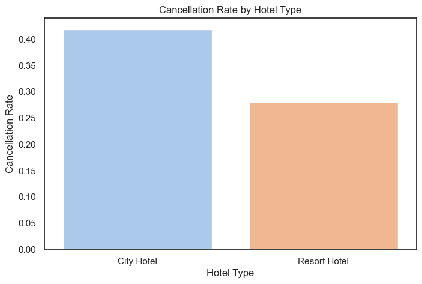

```python
cancel_by_hotel = hotel_df.groupby('hotel')['is_canceled'].mean().reset_index()

sns.barplot(data=cancel_by_hotel, x='hotel', y='is_canceled', hue='hotel',
            palette='pastel', legend=False)

plt.title('Cancellation Rate by Hotel Type')
plt.xlabel('Hotel Type')
plt.ylabel('Cancellation Rate')
plt.show()
```

### 2. 여행사 이용 여부별 취소율

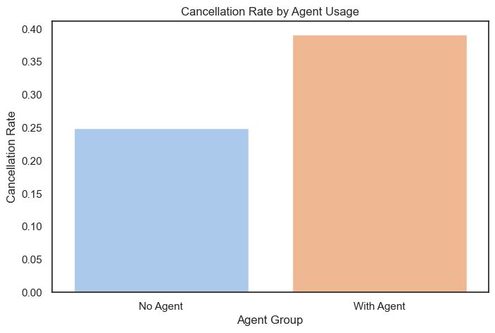

```python
cancel_by_agent = hotel_df.groupby('agent_group')['is_canceled'].mean().reset_index()

sns.barplot(data=cancel_by_agent, x='agent_group', y='is_canceled', hue='agent_group',
            palette='pastel', legend=False)

plt.title('Cancellation Rate by Agent Usage')
plt.xlabel('Agent Group')
plt.ylabel('Cancellation Rate')
plt.show()
```

### 3. 유통 채널별 취소율

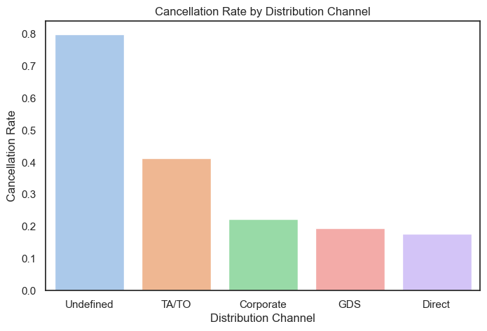

```python
cancel_by_channel = (hotel_df.groupby('distribution_channel')['is_canceled'].mean()
                     .reset_index().sort_values('is_canceled', ascending=False))

sns.barplot(data=cancel_by_channel, x='distribution_channel', y='is_canceled',
            hue='distribution_channel', palette='pastel', legend=False)

plt.title('Cancellation Rate by Distribution Channel')
plt.xlabel('Distribution Channel')
plt.ylabel('Cancellation Rate')
plt.show()
```

### 4. 리드타임 조건별 취소율

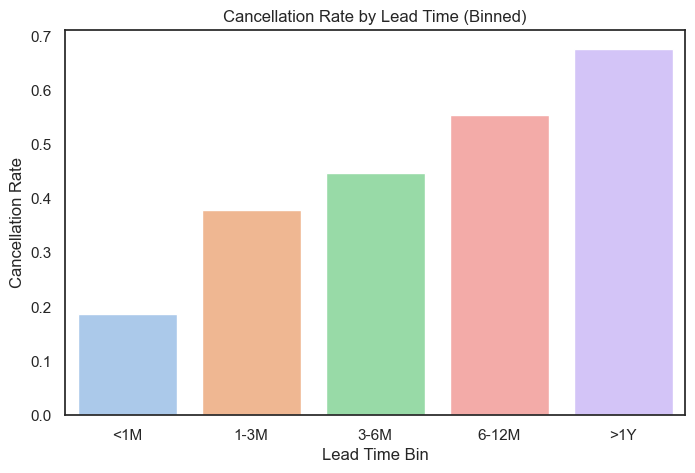

```python
cancel_by_lead = hotel_df.groupby('lead_time_bin')['is_canceled'].mean().reset_index()

sns.barplot(data=cancel_by_lead, x='lead_time_bin', y='is_canceled',
            hue='lead_time_bin', palette='pastel', legend=False)

plt.title('Cancellation Rate by Lead Time (Binned)')
plt.xlabel('Lead Time Bin')
plt.ylabel('Cancellation Rate')
plt.show()
```

### 5. 대기 여부별 취소율

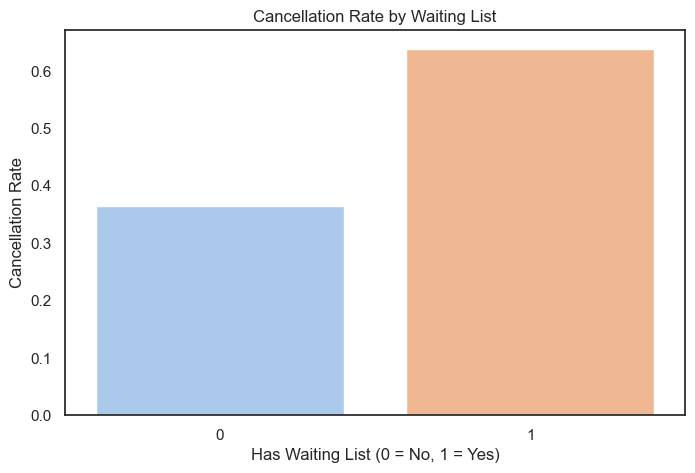

```python
cancel_by_waiting = (hotel_df.groupby('has_waiting')['is_canceled'].mean()
                     .reset_index())

sns.barplot(data=cancel_by_waiting, x='has_waiting', y='is_canceled',
            hue='has_waiting', palette='pastel', legend=False)

plt.title('Cancellation Rate by Waiting List')
plt.xlabel('Has Waiting List (0 = No, 1 = Yes)')
plt.ylabel('Cancellation Rate')
plt.show()
```

** 그외에 그래프 (반복 방문 고객별/예약 변경 횟수별/특별 요청수 별 취소율)는 살짝 지저분하고 복잡해질 수 있을 것 같아 따로 그래프로 넣지 않았음.

## 최종 인사이트 요약

앞선 1차, 2차, 3차 분석을 종합하여  
호텔 예약 취소와 가장 밀접하게 연관된 요인들을 정리한다.  
본 분석은 **예약 시점에 알 수 있는 정보**를 기준으로,  
취소를 사전에 예방할 수 있는 조건을 도출하는 데 목적이 있다.

### 1. 취소율이 높은 주요 집단

- **City Hotel**의 취소율은 Resort Hotel보다 현저히 높게 나타났다.
- **여행사를 통한 예약(With Agent)**은  
  직접 예약(No Agent)에 비해 취소율이 높았다.
- **TA/TO 유통 채널**은 다른 채널 대비 취소율이 높아  
  우선 관리 대상 채널로 확인되었다.

-> 도심 호텔 + 여행사 경유 예약은  
취소 관리가 필요한 핵심 대상군이다.

### 2. 취소를 유발하는 핵심 조건

- **예약 리드타임(lead_time)**이 길어질수록  
  취소율이 단조 증가하는 패턴이 나타났다.
- **대기 경험(has_waiting)**이 있는 예약은  
  대기 경험이 없는 예약에 비해 취소율이 매우 높았다.
- 반면, **예약 변경이 발생한 경우**는  
  오히려 예약 유지 의도가 높아  
  취소율이 낮아지는 경향을 보였다.

-> 장기 예약 + 대기 상태는  
취소 가능성을 크게 높이는 위험 조건이다.

### 3. 취소율이 낮은 안정적인 고객 성향

- **반복 방문 고객(is_repeated_guest)**은  
  취소율이 낮은 안정적인 고객군으로 확인되었다.
- **특별 요청(total_of_special_requests)**이 있는 고객은  
  예약 의도가 명확하여 취소 가능성이 상대적으로 낮았다.
- 식사 유형 중에서는 **FB(Full Board)** 예약의  
  취소율이 가장 높게 나타났다.

-> 반복 방문 고객과  
특별 요청이 있는 고객은 신뢰도가 높은 핵심 고객군이다.

### 4. 가장 위험한 예약 조합

- **City Hotel**
- **여행사 경유 예약**
- **장기 예약(6개월 이상)**
- **대기 경험 있음**

이는 호텔 관리인이  
사전에 집중 관리해야 할 최우선 대상 예약 유형으로 판단된다.

### 5. 운영 관점에서의 개선 방향

- 장기 예약 고객을 대상으로  
  **리마인드 메시지, 예약 확인 절차 강화**를 고려할 수 있다.
- 여행사 및 TA/TO 채널 예약에 대해  
  **취소 정책 차등 적용** 또는 **보증금 정책 강화**를 검토할 수 있다.
- 반복 방문 고객 및 특별 요청 고객에게는  
  **혜택 제공을 통한 충성도 강화 전략**이 효과적일 수 있다.

본 분석을 통해  
예약 취소는 단일 요인이 아닌,  
고객 성향과 예약 조건이 복합적으로 작용한 결과임을 확인하였다.  
이를 바탕으로 취소율을 사전에 관리할 수 있는  
실질적인 운영 전략을 도출할 수 있다.